# Projet Feature engineering : étude de cas

Prédiction de prix de voitures

*Objectifs* :

Ce Projet a pour but de mettre en oeuvre les méthodes relatives au feature engineering présentées en cours afin d'améliorer la prédiction du prix d'une voiture. Plus particulièrement :

- Identifier le type de chaque variable (quantitative/ordinale/catégorielle) et les transformer de façon adéquate (one hot encoding, standardisation, ...).
- Etudier les relations entre variables pour ajouter de nouvelles features.
- Comprendre la nature des features pour en ajouter de nouvelles.
- Mettre en évidence la pertinence de ces manipulations.

Dans cette séance, les librairies suivantes seront utilisées : installez-les si nécessaire et chargez-les

```python
import pandas as pd
import numpy as np
import seaborn as sns
from sklearn import preprocessing
from matplotlib import pyplot as plt
import time
```

## Table des matières

1 - Jeu de données : présentation et analyse

2 - Transformations essentielles

2-1 One-hot encoding

2-2 Mise à l'échelle

2-3 Résultat de référence

2-4 One-hot encoding vs label encoding

2-5 Oubli de mise à l'échelle

2-6 Sur les données non standardisées et mal encodées

3 Création de features

3-2 Le cas de la variable 'highway MPG' : première approche

3-3 Terme d'interaction

3-4 Encore des transformations ...

4 Et les variables catégorielles ?

4-1 Sont-elles toutes déterminantes ?

5 OneHotEncoder vs get_dummies

## 1 Jeu de données : présentation et analyse

Cette séance est inspirée de [ce travail](https://www.kaggle.com/anirbank/usedcarpriceprediction) et de [celui-ci](https://www.kaggle.com/bryanb/simple-and-quick-eda) et étudie le jeu de données disponible sur [Kaggle](https://www.kaggle.com/CooperUnion/cardataset). Il contient $11902$ observations de $14$ features présentées dans le tableau ci-dessous. Il s'agit de pouvoir prédire le prix de voitures à partir de certaines de leur caractéristiques.

| Nom | Description | Valeurs |  |
| --- | --- | --- | --- |
| Make | marque | {BMW, FIAT, Mercedes-Benz, Chrysler, Nissan, Volvo, |  |
|  |  | Mazda, Mitsubishi, Ferrari, Alfa Romeo, Toyota, |  |
|  |  | McLaren, Maybach, Pontiac, Porsche, Saab, Audi, GMC, |  |
|  |  | Hyundai, Plymouth, Honda, Oldsmobile, Suzuki, Ford, |  |
|  |  | Cadillac, Kia, Bentley, Chevrolet, Dodge, Lamborghini, |  |
|  |  | Lincoln, Subaru, Volkswagen, Spyker, Buick, Acura, |  |
|  |  | Rolls-Royce, Maserati, Lexus, Aston Martin, Land Rover, |  |
|  |  | Lotus, Infiniti, Scion, Genesis, HUMMER, Tesla, |  |
|  |  | Bugatti} |  |
| Year | année de fabrication | $\mathbb{N}$ |  |
| Engine Fuel Type | type de carburant | {0 : 'unleaded', 1 : 'flex-fuel', 2 : 'diesel', |  |
|  |  | 3 : 'electric',4 : 'natural gas'} |  |
| Engine HP | puissance du moteur (hp) | $\mathbb{R}$ |  |
| Engine Cylinders | nombre de cylindre | $\mathbb{N}$ |  |
| Transmission Type | type de transmission | 'MANUAL', 'AUTOMATIC', 'AUTOMATED_MANUAL', 'DIRECT_DRIVE', |  |
|  |  | 'UNKNOWN' |  |
| Driven_Wheels | roues motrices | {rear wheel drive, all wheel drive, front wheel drive,four wheel drive} |  |
| Number of Doors | nombre de portes | $\mathbb{N}$ |  |
| Vehicle Size | taille du véhicule | {Compact, Midsize, Large} |  |
| highway MPG | consommation sur route (en mpg) | $\mathbb{R}$ |  |
| city mpg | consommation en ville (en mpg) | $\mathbb{R}$ |  |
| Popularity | popularité (via twitter) | $\mathbb{R}$ |  |
| MSRP | prix (en \$) | $\mathbb{R}$ |  |

> Importation et visualisation :. Importons et visualisons les données se trouvant dans le fichier *data_cars.csv* fourni. Nous allons utiliser pour cela les méthodes suivantes, se trouvant dans la librairie pandas :
> - read_csv
> - head
> - describe, en particulier, nous pouvons donner à cette fonction le paramètre suivant : *include = 'object'* ou *include = 'int64'* ou *include = 'float64'*,etc ... pour isoler un certain groupe de features.

> ainsi que les attributs :
> - dtypes
> - shape

```python
data = pd.read_csv('data_cars.csv',index_col=0)
data.head()
```

|  | Make | Year | Engine Fuel Type | Engine HP | Engine Cylinders | Transmission Type | Driven_Wheels | Number of Doors | Vehicle Size | Vehicle Style | highway MPG | city mpg | Popularity | MSRP |
| --- | --- | --- | --- | --- | --- | --- | --- | --- | --- | --- | --- | --- | --- | --- |
| 0 | BMW | 2011 | 0 | 335.0 | 6.0 | MANUAL | rear wheel drive | 2.0 | Compact | Coupe | 26 | 19 | 3916 | 46135 |
| 1 | BMW | 2011 | 0 | 300.0 | 6.0 | MANUAL | rear wheel drive | 2.0 | Compact | Convertible | 28 | 19 | 3916 | 40650 |
| 2 | BMW | 2011 | 0 | 300.0 | 6.0 | MANUAL | rear wheel drive | 2.0 | Compact | Coupe | 28 | 20 | 3916 | 36350 |
| 3 | BMW | 2011 | 0 | 230.0 | 6.0 | MANUAL | rear wheel drive | 2.0 | Compact | Coupe | 28 | 18 | 3916 | 29450 |
| 4 | BMW | 2011 | 0 | 230.0 | 6.0 | MANUAL | rear wheel drive | 2.0 | Compact | Convertible | 28 | 18 | 3916 | 34500 |

```python
data.shape
```

```
(11902, 14)
```

```python
data.isna().sum().sum()
```

```
0
```

```python
data.dtypes
```

```
Make                  object
Year                   int64
Engine Fuel Type       int64
Engine HP            float64
Engine Cylinders     float64
Transmission Type     object
Driven_Wheels         object
Number of Doors      float64
Vehicle Size          object
Vehicle Style         object
highway MPG            int64
city mpg               int64
Popularity             int64
MSRP                   int64
dtype: object
```

```python
data.describe(include='object')
```

|  | Make | Transmission Type | Driven_Wheels | Vehicle Size | Vehicle Style |
| --- | --- | --- | --- | --- | --- |
| count | 11902 | 11902 | 11902 | 11902 | 11902 |
| unique | 48 | 5 | 4 | 3 | 16 |
| top | Chevrolet | AUTOMATIC | front wheel drive | Compact | Sedan |
| freq | 1123 | 8261 | 4787 | 4752 | 3048 |

```python
data.describe(include='int64')
```

|  | Year | Engine Fuel Type | highway MPG | city mpg | Popularity | MSRP |
| --- | --- | --- | --- | --- | --- | --- |
| count | 11902.000000 | 11902.000000 | 11902.000000 | 11902.000000 | 11902.000000 | 1.190200e+04 |
| mean | 2010.397832 | 0.126197 | 26.644850 | 19.738615 | 1555.278441 | 4.061092e+04 |
| std | 7.571463 | 0.414068 | 8.863755 | 8.990560 | 1442.285873 | 6.013677e+04 |
| min | 1990.000000 | 0.000000 | 12.000000 | 7.000000 | 2.000000 | 2.000000e+03 |
| 25% | 2007.000000 | 0.000000 | 22.000000 | 16.000000 | 549.000000 | 2.101750e+04 |
| 50% | 2015.000000 | 0.000000 | 26.000000 | 18.000000 | 1385.000000 | 2.999500e+04 |
| 75% | 2016.000000 | 0.000000 | 30.000000 | 22.000000 | 2009.000000 | 4.226500e+04 |
| max | 2017.000000 | 4.000000 | 354.000000 | 137.000000 | 5657.000000 | 2.065902e+06 |

```python
data.describe(include='float64')
```

|  | Engine HP | Engine Cylinders | Number of Doors |
| --- | --- | --- | --- |
| count | 11902.000000 | 11902.000000 | 11902.000000 |
| mean | 249.397363 | 5.616955 | 3.438162 |
| std | 108.916386 | 1.792268 | 0.880947 |
| min | 55.000000 | 0.000000 | 2.000000 |
| 25% | 170.000000 | 4.000000 | 2.000000 |
| 50% | 227.000000 | 6.000000 | 4.000000 |
| 75% | 300.000000 | 6.000000 | 4.000000 |
| max | 1001.000000 | 16.000000 | 5.000000 |

Repérons la feature qui est de type 'int64' mais qu'il serait plus logique de transformer en 'object' car c'est une variable catégorielle.

```python
mapping_fuel = {
        0 : 'unleaded',
        1 : 'flex-fuel',
        2 : 'diesel',
        3 : 'electric',
        4 : 'natural gas'
}
data['Engine Fuel Type']=data['Engine Fuel Type'].replace(mapping_fuel)
```

```python
data.head()
```

|  | Make | Year | Engine Fuel Type | Engine HP | Engine Cylinders | Transmission Type | Driven_Wheels | Number of Doors | Vehicle Size | Vehicle Style | highway MPG | city mpg | Popularity | MSRP |
| --- | --- | --- | --- | --- | --- | --- | --- | --- | --- | --- | --- | --- | --- | --- |
| 0 | BMW | 2011 | unleaded | 335.0 | 6.0 | MANUAL | rear wheel drive | 2.0 | Compact | Coupe | 26 | 19 | 3916 | 46135 |
| 1 | BMW | 2011 | unleaded | 300.0 | 6.0 | MANUAL | rear wheel drive | 2.0 | Compact | Convertible | 28 | 19 | 3916 | 40650 |
| 2 | BMW | 2011 | unleaded | 300.0 | 6.0 | MANUAL | rear wheel drive | 2.0 | Compact | Coupe | 28 | 20 | 3916 | 36350 |
| 3 | BMW | 2011 | unleaded | 230.0 | 6.0 | MANUAL | rear wheel drive | 2.0 | Compact | Coupe | 28 | 18 | 3916 | 29450 |
| 4 | BMW | 2011 | unleaded | 230.0 | 6.0 | MANUAL | rear wheel drive | 2.0 | Compact | Convertible | 28 | 18 | 3916 | 34500 |

> Les variables
> - quantitatives ?
> - catégorielles ?
> - ordinales ?

```python
list_q=['Year','highway MPG','city mpg','Engine HP', 'Engine Cylinders','Number of Doors','Popularity']#variables quantitatives sans la variable à prédire 'price'
list_c=['Make','Transmission Type','Driven_Wheels','Vehicle Style','Engine Fuel Type']#variables catégorielles
list_o=['Vehicle Size']#variables ordinales
```

> Tâche 4. Labellisons la variable ordinale à l'aide du code ci-dessous :

```python
data['Vehicle Size'].unique()
```

```
array(['Compact', 'Midsize', 'Large'], dtype=object)
```

```python
#mettre au bon format
mapping_ordinal = {
        'Compact': 0,
        'Midsize' : 1,
        'Large': 2
}
data['Vehicle Size']=data['Vehicle Size'].replace(mapping_ordinal)
```

```python
data['Vehicle Size'].dtypes
```

```
dtype('int64')
```

```python
data.dtypes
```

```
Make                  object
Year                   int64
Engine Fuel Type      object
Engine HP            float64
Engine Cylinders     float64
Transmission Type     object
Driven_Wheels         object
Number of Doors      float64
Vehicle Size           int64
Vehicle Style         object
highway MPG            int64
city mpg               int64
Popularity             int64
MSRP                   int64
dtype: object
```

> Tâche 5. Visualisons les gammes de prix des différentes marques de véhicule à l'aide de la fonction boxplot de la librairie seaborn.

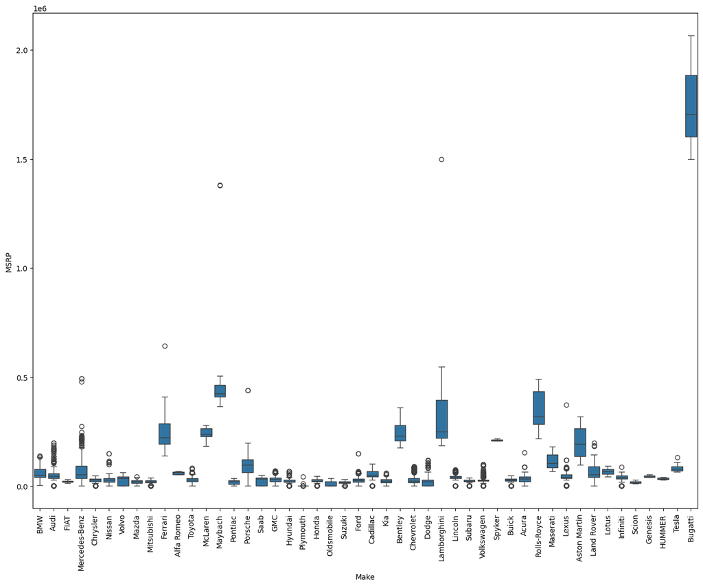

```python
plt.figure(figsize=(16, 12))
ax = sns.boxplot(x='Make', y='MSRP', data=data)
ax.set_xticklabels(ax.get_xticklabels(),rotation=90);
```

Tâche 6. Il apparaît que ce jeu de données renferme des marques aux gammes de prix très hétérogènes. Visualisons le prix médian de chaque marque à l'aide de la fonction groupby de la librairie pandas.

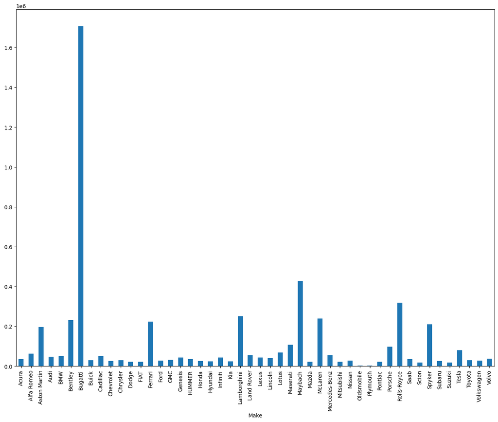

```python
Make=data.groupby(['Make'])['MSRP'].median()
plt.figure(figsize=(16, 12))
Make.plot(kind='bar', stacked=True)
```

Tâche 7. Il semble judicieux de traiter des groupes de marques différemment selon leur gamme de prix. A l'aide des fonctions groupby et join de la librairie pandas, gardons uniquement dans le jeu de données les marques de prix médian inférieur à $30000$\$.

```python
data=data.join(data.groupby('Make')['MSRP'].median(), on='Make', rsuffix='_Median')
data=data[data['MSRP_Median']<30000]
data=data.drop(['MSRP_Median'],axis=1)
data.reset_index(drop=True,inplace=True)

#Autre possibilité (sans utiliser 'join') :
#marquesAConserver = data.groupby(by='Make')['MSRP'].median()<30000
#marquesAConserver # marque True/False
#idxAConserver = data['Make'].apply(lambda x: marquesAConserver[x])
#data=data[idxAConserver]
```

```python
data.head()
```

|  | Make | Year | Engine Fuel Type | Engine HP | Engine Cylinders | Transmission Type | Driven_Wheels | Number of Doors | Vehicle Size | Vehicle Style | highway MPG | city mpg | Popularity | MSRP |
| --- | --- | --- | --- | --- | --- | --- | --- | --- | --- | --- | --- | --- | --- | --- |
| 0 | FIAT | 2017 | unleaded | 160.0 | 4.0 | MANUAL | rear wheel drive | 2.0 | 0 | Convertible | 35 | 26 | 819 | 27495 |
| 1 | FIAT | 2017 | unleaded | 160.0 | 4.0 | MANUAL | rear wheel drive | 2.0 | 0 | Convertible | 35 | 26 | 819 | 24995 |
| 2 | FIAT | 2017 | unleaded | 160.0 | 4.0 | MANUAL | rear wheel drive | 2.0 | 0 | Convertible | 35 | 26 | 819 | 28195 |
| 3 | Chrysler | 2015 | flex-fuel | 184.0 | 4.0 | AUTOMATIC | front wheel drive | 4.0 | 1 | Sedan | 36 | 23 | 1013 | 25170 |
| 4 | Chrysler | 2015 | flex-fuel | 184.0 | 4.0 | AUTOMATIC | front wheel drive | 4.0 | 1 | Sedan | 36 | 23 | 1013 | 23950 |

```python
data.index
```

```
RangeIndex(start=0, stop=6948, step=1)
```

```python
data.shape
```

```
(6948, 14)
```

> Tâche 8. Vérifions qu'il n'il y pas d'outliers dans les valeurs des prix que nous avons gardé avec la fonction boxplot de la librairie seaborn et enlevez-les le cas échéant. Combien de marques avons-nous gardées jusqu'à présent ?

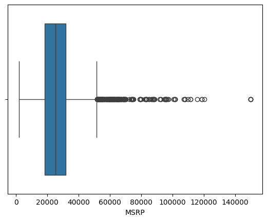

```python
sns.boxplot(x=data['MSRP'])
```

```python
data=data[data['MSRP']<140000]
data.reset_index(drop=True,inplace=True)
```

```python
data.shape
```

```
(6944, 14)
```

```python
data.index
```

```
RangeIndex(start=0, stop=6944, step=1)
```

```python
data['Make'].nunique()
```

```
18
```

On restreint encore le nombre catégories en sélectionnant uniquement les marques suivantes : 'Ford', 'Chevrolet', 'Chrysler','Pontiac', 'Subaru', 'Hyundai', 'Honda', 'Mazda', 'Nissan' et 'Suzuki'.

```python
Makes=['Ford','Chevrolet','Chrysler','Pontiac','Subaru',
       'Hyundai','Honda','Mazda', 'Nissan','Suzuki']
data=data[data.Make.isin(Makes)]
data.reset_index(drop=True,inplace=True)
```

> Tâche 9. Effectuons une analyse préliminaire des relations entre ces variables, qui pourra nous mettre sur la piste des transformations et créations de feature à réaliser. Pour cela :
> - Regardons quelles sont les corrélations entre les variables quantitatives à l'aide des fonctions corr de pandas et heatmap de la librairie seaborn. Même chose pour les variables ordinales.
> - Visualisons les nuages de points et leur tendance linéaire ou non entre les différentes variables quantitatives et la variable que l'on veut prédire, 'MSRP', en utilisant la fonction regplot de la librairie seaborn. Même chose pour les variables ordinales.
> - Visualisons les boxplots des différentes variables catégorielles relativement à la variable 'price' en utilisant la fonction boxplot de la librairie seaborn.

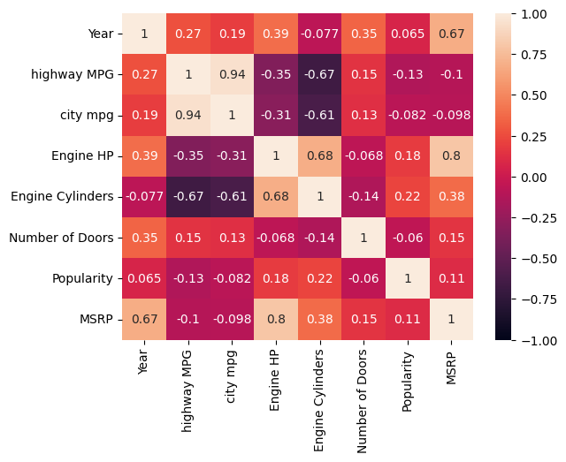

```python
#correlation plot
corr = data[list_q+['MSRP']].corr()
sns.heatmap(corr, vmin=-1, vmax=1,annot=True)
```

```python
print(corr)
```

```
                      Year  highway MPG  city mpg  Engine HP  \
Year              1.000000     0.273192  0.194467   0.385689
highway MPG       0.273192     1.000000  0.941720  -0.347818
city mpg          0.194467     0.941720  1.000000  -0.311200
Engine HP         0.385689    -0.347818 -0.311200   1.000000
Engine Cylinders -0.076539    -0.669115 -0.609996   0.683590
Number of Doors   0.346771     0.147321  0.131062  -0.068304
Popularity        0.065101    -0.132642 -0.081767   0.181885
MSRP              0.672539    -0.104344 -0.098190   0.801281

                  Engine Cylinders  Number of Doors  Popularity      MSRP
Year                     -0.076539         0.346771    0.065101  0.672539
highway MPG              -0.669115         0.147321   -0.132642 -0.104344
city mpg                 -0.609996         0.131062   -0.081767 -0.098190
Engine HP                 0.683590        -0.068304    0.181885  0.801281
Engine Cylinders          1.000000        -0.135039    0.218940  0.382778
Number of Doors          -0.135039         1.000000   -0.060286  0.150105
Popularity                0.218940        -0.060286    1.000000  0.108686
MSRP                      0.382778         0.150105    0.108686  1.000000
```

```python
print(np.abs(corr['MSRP']).sort_values(ascending=False))
```

```
MSRP                1.000000
Engine HP           0.801281
Year                0.672539
Engine Cylinders    0.382778
Number of Doors     0.150105
Popularity          0.108686
highway MPG         0.104344
city mpg            0.098190
Name: MSRP, dtype: float64
```

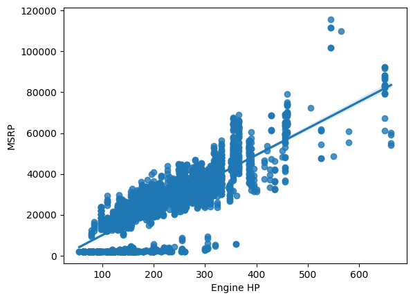

```python
sns.regplot(x="Engine HP", y="MSRP", data=data)
```

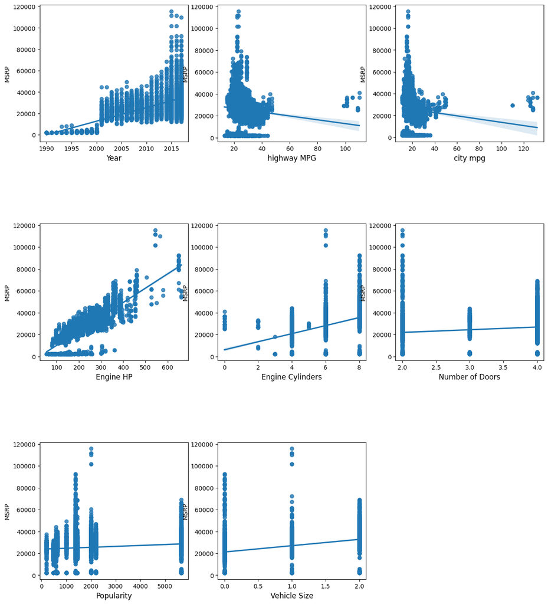

```python
# subplots for loop to get all the graphs
rowCnt = len(list_q+list_o)
colCnt = 3
subCnt = 1

fig = plt.figure(figsize=(15,50))
fig.subplots_adjust(hspace = .6)

for i in (list_q+list_o):
    fig.add_subplot(rowCnt, colCnt, subCnt)
    plt.xlabel(i, fontsize=12)
    sns.regplot(x=data[[i]], y="MSRP", data=data)
    subCnt = subCnt + 1

plt.show()

#Autre possibilité :
#sns.pairplot(data, kind='reg')
```

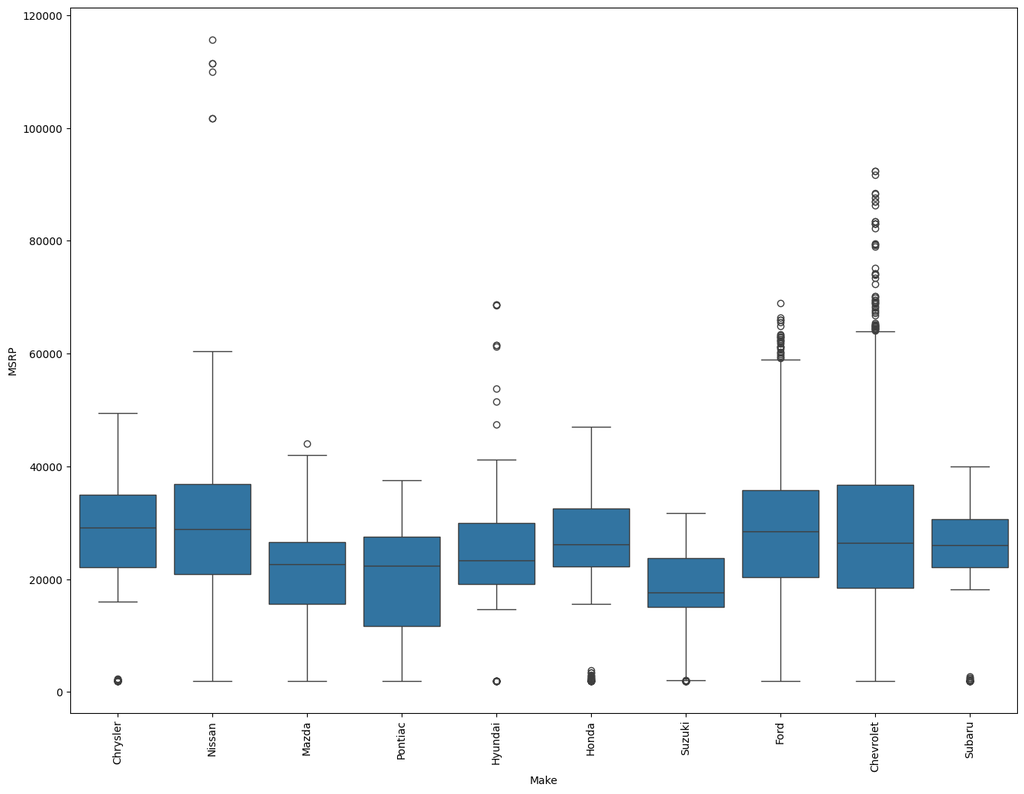

```python
plt.figure(figsize=(16, 12))
ax = sns.boxplot(x='Make', y='MSRP', data=data)
ax.set_xticklabels(ax.get_xticklabels(),rotation=90);
```

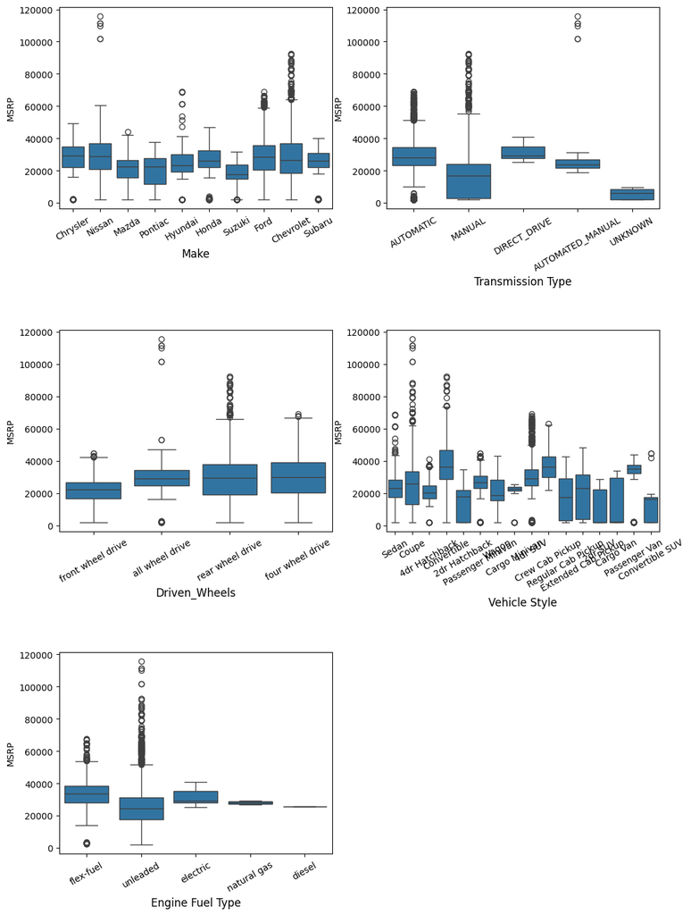

```python
#  subplots for loop to get all the graphs
rowCnt = len(list_c)
colCnt = 2
subCnt = 1

fig = plt.figure(figsize=(12,30))
fig.subplots_adjust(hspace = .6)

for i in list_c:
    fig.add_subplot(rowCnt, colCnt, subCnt)
    plt.xlabel(i, fontsize=12)
    ax = sns.boxplot(x=data[i], y='MSRP', data=data)
    ax.set_xticklabels(ax.get_xticklabels(),rotation=30);
    subCnt = subCnt + 1

plt.show()
```

'Highway MPG' et 'city mpg' étant fortement corrélées, on ne garde que 'highway MPG' dans le jeu de données. On écarte également 'Popularity' qui semble peu pertinent.

```python
data=data.drop(['city mpg','Popularity'],axis=1)
```

```python
data.head()
```

|  | Make | Year | Engine Fuel Type | Engine HP | Engine Cylinders | Transmission Type | Driven_Wheels | Number of Doors | Vehicle Size | Vehicle Style | highway MPG | MSRP |
| --- | --- | --- | --- | --- | --- | --- | --- | --- | --- | --- | --- | --- |
| 0 | Chrysler | 2015 | flex-fuel | 184.0 | 4.0 | AUTOMATIC | front wheel drive | 4.0 | 1 | Sedan | 36 | 25170 |
| 1 | Chrysler | 2015 | flex-fuel | 184.0 | 4.0 | AUTOMATIC | front wheel drive | 4.0 | 1 | Sedan | 36 | 23950 |
| 2 | Chrysler | 2015 | flex-fuel | 295.0 | 6.0 | AUTOMATIC | all wheel drive | 4.0 | 1 | Sedan | 29 | 29370 |
| 3 | Chrysler | 2015 | flex-fuel | 184.0 | 4.0 | AUTOMATIC | front wheel drive | 4.0 | 1 | Sedan | 36 | 21995 |
| 4 | Chrysler | 2015 | flex-fuel | 184.0 | 4.0 | AUTOMATIC | front wheel drive | 4.0 | 1 | Sedan | 36 | 26625 |

Retour à la table des matières

## 2 Transformations essentielles

### 2-1 One-hot encoding

Nous allons maintenant transformer les variables catégorielles en utilisant l'encodage one-hot vu en cours. Pour cela nous utiliserons la fonction OneHotEncoder se trouvant dans le module preprocessing de la librairie sklearn. Installez-la si nécessaire et importez-la :

```python
from sklearn.preprocessing import OneHotEncoder
```

> Tâche 10. Le code ci-dessous détaille pas-à-pas comment effectuer l'encodage one-hot. Expliquons pourquoi nous allons encoder les variables 'Number of Doors', 'Vehicle Size' et 'Engine Cylinders' en one-hot ?

```python
list_o
```

```
['Vehicle Size']
```

```python
list_one_hot=list_c+list_o + ['Number of Doors','Engine Cylinders']
#On crée l'objet 'encoder_OH'
encoder_OH = OneHotEncoder(handle_unknown='error',sparse_output=False)
#On ajuste nos données à l'objet 'encoder_OH'
fit_OH=encoder_OH.fit(data[list_one_hot])
#On transforme nos données catégorielles grâce à l'objet 'encoder_OH'
fit_data_OH=fit_OH.transform(data[list_one_hot])
#On récupère les noms pour nos nouvelles colonnes
column_name_OH =fit_OH.get_feature_names_out(list_one_hot)
#On met nos données transformées sous forme de Dataframe
cols_OH = pd.DataFrame(fit_data_OH,columns=column_name_OH)
#on réinitialise l'index
cols_OH.reset_index(drop=True, inplace=True)
```

```python
list_one_hot
```

```
['Make',
 'Transmission Type',
 'Driven_Wheels',
 'Vehicle Style',
 'Engine Fuel Type',
 'Vehicle Size',
 'Number of Doors',
 'Engine Cylinders']
```

```python
cols_OH.isna().sum().sum()
```

```
0
```

```python
cols_OH.head()
```

|  | Make_Chevrolet | Make_Chrysler | Make_Ford | Make_Honda | Make_Hyundai | Make_Mazda | Make_Nissan | Make_Pontiac | Make_Subaru | Make_Suzuki | ... | Number of Doors_2.0 | Number of Doors_3.0 | Number of Doors_4.0 | Engine Cylinders_0.0 | Engine Cylinders_2.0 | Engine Cylinders_3.0 | Engine Cylinders_4.0 | Engine Cylinders_5.0 | Engine Cylinders_6.0 | Engine Cylinders_8.0 |
| --- | --- | --- | --- | --- | --- | --- | --- | --- | --- | --- | --- | --- | --- | --- | --- | --- | --- | --- | --- | --- | --- |
| 0 | 0.0 | 1.0 | 0.0 | 0.0 | 0.0 | 0.0 | 0.0 | 0.0 | 0.0 | 0.0 | ... | 0.0 | 0.0 | 1.0 | 0.0 | 0.0 | 0.0 | 1.0 | 0.0 | 0.0 | 0.0 |
| 1 | 0.0 | 1.0 | 0.0 | 0.0 | 0.0 | 0.0 | 0.0 | 0.0 | 0.0 | 0.0 | ... | 0.0 | 0.0 | 1.0 | 0.0 | 0.0 | 0.0 | 1.0 | 0.0 | 0.0 | 0.0 |
| 2 | 0.0 | 1.0 | 0.0 | 0.0 | 0.0 | 0.0 | 0.0 | 0.0 | 0.0 | 0.0 | ... | 0.0 | 0.0 | 1.0 | 0.0 | 0.0 | 0.0 | 0.0 | 0.0 | 1.0 | 0.0 |
| 3 | 0.0 | 1.0 | 0.0 | 0.0 | 0.0 | 0.0 | 0.0 | 0.0 | 0.0 | 0.0 | ... | 0.0 | 0.0 | 1.0 | 0.0 | 0.0 | 0.0 | 1.0 | 0.0 | 0.0 | 0.0 |
| 4 | 0.0 | 1.0 | 0.0 | 0.0 | 0.0 | 0.0 | 0.0 | 0.0 | 0.0 | 0.0 | ... | 0.0 | 0.0 | 1.0 | 0.0 | 0.0 | 0.0 | 1.0 | 0.0 | 0.0 | 0.0 |

5 rows × 53 columns

```python
cols_OH.shape
```

```
(4713, 53)
```

```python
data.shape
```

```
(4713, 12)
```

> Tâche 11. Nous allons vérifier que le code précédent est correct, c'est-à-dire qu'il effectue bien ce qu'on attend de lui.
> - Combien de variables catégorielles avions-nous avant transformation ? Avec combien de catégories chacunes ? Combien de variables 'one-hot' avons nous après transformations ? Cela est-il cohérent ?
> - Visualisons le nom des colonnes de nos nouvelles variables en utilisant la commande list(cols_train_OH.columns). Est-ce que ces noms sont cohérents et utiles ?

```python
data[list_one_hot].nunique()
```

```
Make                 10
Transmission Type     5
Driven_Wheels         4
Vehicle Style        16
Engine Fuel Type      5
Vehicle Size          3
Number of Doors       3
Engine Cylinders      7
dtype: int64
```

```python
data[list_one_hot].nunique().sum()
```

```
53
```

```python
 list(cols_OH.columns)
```

```
['Make_Chevrolet',
 'Make_Chrysler',
 'Make_Ford',
 'Make_Honda',
 'Make_Hyundai',
 'Make_Mazda',
 'Make_Nissan',
 'Make_Pontiac',
 'Make_Subaru',
 'Make_Suzuki',
 'Transmission Type_AUTOMATED_MANUAL',
 'Transmission Type_AUTOMATIC',
 'Transmission Type_DIRECT_DRIVE',
 'Transmission Type_MANUAL',
 'Transmission Type_UNKNOWN',
 'Driven_Wheels_all wheel drive',
 'Driven_Wheels_four wheel drive',
 'Driven_Wheels_front wheel drive',
 'Driven_Wheels_rear wheel drive',
 'Vehicle Style_2dr Hatchback',
 'Vehicle Style_2dr SUV',
 'Vehicle Style_4dr Hatchback',
 'Vehicle Style_4dr SUV',
 'Vehicle Style_Cargo Minivan',
 'Vehicle Style_Cargo Van',
 'Vehicle Style_Convertible',
 'Vehicle Style_Convertible SUV',
 'Vehicle Style_Coupe',
 'Vehicle Style_Crew Cab Pickup',
 'Vehicle Style_Extended Cab Pickup',
 'Vehicle Style_Passenger Minivan',
 'Vehicle Style_Passenger Van',
 'Vehicle Style_Regular Cab Pickup',
 'Vehicle Style_Sedan',
 'Vehicle Style_Wagon',
 'Engine Fuel Type_diesel',
 'Engine Fuel Type_electric',
 'Engine Fuel Type_flex-fuel',
 'Engine Fuel Type_natural gas',
 'Engine Fuel Type_unleaded',
 'Vehicle Size_0',
 'Vehicle Size_1',
 'Vehicle Size_2',
 'Number of Doors_2.0',
 'Number of Doors_3.0',
 'Number of Doors_4.0',
 'Engine Cylinders_0.0',
 'Engine Cylinders_2.0',
 'Engine Cylinders_3.0',
 'Engine Cylinders_4.0',
 'Engine Cylinders_5.0',
 'Engine Cylinders_6.0',
 'Engine Cylinders_8.0']
```

> Commentaires sur l'ensemble de la section 2. Nous avons créé $53$ variables : on passe ainsi de $8$ variables catégorielles à $10$, $5$, $4$, $16$, $5$, $3$, $3$ et $7$ catégories à $53$ variables binaires.

> Les nouveaux noms nous aide à identifier clairement la signification de chaque colonne : il est important de les garder pour l'interprétation des résultats après modélisation, pour l'exploitation et l'interprétation du modèle.

Retour à la table des matières

### 2-2 Mise à l'échelle

Nous allons maintenant mettre à l'échelle les variables quantitatives restantes en utilisant la standardisation vue en cours. Pour cela nous utiliserons la fonction StandardScaler se trouvant dans le module preprocessing de la librairie sklearn. Installez-la si nécessaire et importez-la :

```python
from sklearn.preprocessing import StandardScaler
```

> Tâche 12. Le code ci-dessous détaille pas-à-pas comment effectuer la standardisation.

```python
list_std=['Year','Engine HP','highway MPG']
#On crée l'objet 'scale'
scale = StandardScaler()
#On ajuste nos données à l'objet 'scale'
fit_scale_OH=scale.fit_transform(data[list_std])
#On met sous forme de Dataframe
cols_scaled = pd.DataFrame(fit_scale_OH,columns=list_std)
cols_scaled.reset_index(drop=True, inplace=True)
```

> Tâche 13. Nous allons vérifier que le code précédent est correct, c'est-à-dire qu'il effectue bien ce qu'on attend de lui.
> - Combien de variables avions-nous avant transformation ? Combien de variables avons-nous après transformation ?
> - Visualisons les nouvelles variables en utilisant la commande describe. Est-ce que cela est cohérent ?

```python
print(data[list_std].shape)
print(cols_scaled.isna().sum().sum())
```

```
(4713, 3)
0
```

```python
cols_scaled.describe()
```

|  | Year | Engine HP | highway MPG |
| --- | --- | --- | --- |
| count | 4.713000e+03 | 4.713000e+03 | 4.713000e+03 |
| mean | -1.409024e-14 | 1.206098e-16 | 3.919820e-17 |
| std | 1.000106e+00 | 1.000106e+00 | 1.000106e+00 |
| min | -2.716993e+00 | -1.906046e+00 | -1.686967e+00 |
| 25% | -6.861856e-01 | -7.409412e-01 | -6.087308e-01 |
| 50% | 5.322987e-01 | -2.166440e-01 | -1.295145e-01 |
| 75% | 8.030730e-01 | 6.571846e-01 | 4.695059e-01 |
| max | 9.384601e-01 | 5.166140e+00 | 9.934028e+00 |

> Tâche 14. Concaténons les deux parties (variables quantitatives standardisées et variables catégorielles encodées en un seul Dataframe *X_init_OH*.

```python
X_init_OH = pd.concat([cols_scaled, cols_OH], axis=1)
```

```python
X_init_OH.describe()
```

|  | Year | Engine HP | highway MPG | Make_Chevrolet | Make_Chrysler | Make_Ford | Make_Honda | Make_Hyundai | Make_Mazda | Make_Nissan | ... | Number of Doors_2.0 | Number of Doors_3.0 | Number of Doors_4.0 | Engine Cylinders_0.0 | Engine Cylinders_2.0 | Engine Cylinders_3.0 | Engine Cylinders_4.0 | Engine Cylinders_5.0 | Engine Cylinders_6.0 | Engine Cylinders_8.0 |
| --- | --- | --- | --- | --- | --- | --- | --- | --- | --- | --- | --- | --- | --- | --- | --- | --- | --- | --- | --- | --- | --- |
| count | 4.713000e+03 | 4.713000e+03 | 4.713000e+03 | 4713.000000 | 4713.000000 | 4713.000000 | 4713.000000 | 4713.000000 | 4713.000000 | 4713.000000 | ... | 4713.000000 | 4713.000000 | 4713.000000 | 4713.000000 | 4713.000000 | 4713.000000 | 4713.000000 | 4713.000000 | 4713.000000 | 4713.000000 |
| mean | -1.409024e-14 | 1.206098e-16 | 3.919820e-17 | 0.238277 | 0.039677 | 0.186505 | 0.095268 | 0.064290 | 0.089752 | 0.117972 | ... | 0.235731 | 0.053469 | 0.710800 | 0.004880 | 0.004244 | 0.002758 | 0.454275 | 0.001061 | 0.401655 | 0.131127 |
| std | 1.000106e+00 | 1.000106e+00 | 1.000106e+00 | 0.426075 | 0.195221 | 0.389555 | 0.293616 | 0.245295 | 0.285856 | 0.322609 | ... | 0.424500 | 0.224991 | 0.453439 | 0.069695 | 0.065011 | 0.052453 | 0.497958 | 0.032558 | 0.490285 | 0.337575 |
| min | -2.716993e+00 | -1.906046e+00 | -1.686967e+00 | 0.000000 | 0.000000 | 0.000000 | 0.000000 | 0.000000 | 0.000000 | 0.000000 | ... | 0.000000 | 0.000000 | 0.000000 | 0.000000 | 0.000000 | 0.000000 | 0.000000 | 0.000000 | 0.000000 | 0.000000 |
| 25% | -6.861856e-01 | -7.409412e-01 | -6.087308e-01 | 0.000000 | 0.000000 | 0.000000 | 0.000000 | 0.000000 | 0.000000 | 0.000000 | ... | 0.000000 | 0.000000 | 0.000000 | 0.000000 | 0.000000 | 0.000000 | 0.000000 | 0.000000 | 0.000000 | 0.000000 |
| 50% | 5.322987e-01 | -2.166440e-01 | -1.295145e-01 | 0.000000 | 0.000000 | 0.000000 | 0.000000 | 0.000000 | 0.000000 | 0.000000 | ... | 0.000000 | 0.000000 | 1.000000 | 0.000000 | 0.000000 | 0.000000 | 0.000000 | 0.000000 | 0.000000 | 0.000000 |
| 75% | 8.030730e-01 | 6.571846e-01 | 4.695059e-01 | 0.000000 | 0.000000 | 0.000000 | 0.000000 | 0.000000 | 0.000000 | 0.000000 | ... | 0.000000 | 0.000000 | 1.000000 | 0.000000 | 0.000000 | 0.000000 | 1.000000 | 0.000000 | 1.000000 | 0.000000 |
| max | 9.384601e-01 | 5.166140e+00 | 9.934028e+00 | 1.000000 | 1.000000 | 1.000000 | 1.000000 | 1.000000 | 1.000000 | 1.000000 | ... | 1.000000 | 1.000000 | 1.000000 | 1.000000 | 1.000000 | 1.000000 | 1.000000 | 1.000000 | 1.000000 | 1.000000 |

8 rows × 56 columns

```python
X_init_OH.shape
```

```
(4713, 56)
```

```python
X_init_OH.isna().sum().sum()
```

```
0
```

> Commentaire sur la section 2-2 On garde le même nombre de variables quantitatives, soit $3$. Au total, notre jeu de données transformé contient $56$ features et $4713$ observations.

> Ici j'ai privilégié la standardisation car c'est la mise à l'échelle la plus couramment recommandée lorsque l'on utilise des algorithmes qui requièrent une mise à l'échelle (ACP, SVM, ...).

> Sur d'autres jeux de données, il peut être plus intéressant d'utiliser la normalisation (pas vue en cours) ou la mise à l'échelle min-max.

Retour à la table des matières

### 2-3 Résultat de référence

Nous souhaitons vérifier que ces transformations sont bien utiles et que l'augmentation de la dimension qui en découle n'est pas délétère.

Pour cela nous allons utiliser les fonctions score_model_1 et score_model_2 suivantes. Il n'est pas nécessaire de comprendre exactement de ce que font ces fonctions, vous pouvez vous en servir comme d'une boîte noire qui vous indique à quel point vos données sont bien préparées : plus le score est **petit**, **meilleur** est votre jeu de données.

Nous utiliserons aussi les méthodes ci-dessous issues de sklearn.

```python
from sklearn.linear_model import LinearRegression,SGDRegressor
from sklearn.metrics import mean_squared_error,r2_score
from sklearn.model_selection import train_test_split
```

```python
def score_model_1(X_train,y_train,X_test,y_test):
    #on crée l'objet modèle linéaire
    regr = LinearRegression()

    #on ajuste le modèle sur les données d'entrainement et on enregistre et affiche le temps nécessaire pour cela
    start = time.time()
    regr.fit(X_train, y_train)
    end = time.time()
    print('Temps d execution du modèle 1 : ' "{:e}".format(end - start))

    #On fait des prédictions sur les données de l'enseble de test
    prix_y_pred = regr.predict(X_test)

    #On affiche le score du modèle
    print('Score MSE sur le modele 1 : ')
    print("{:e}".format(mean_squared_error(y_test, prix_y_pred)))
    print('Score R2 sur le modele 1 : ')
    print(r2_score(y_test, prix_y_pred))
```

```python
def score_model_2(X_train,y_train,X_test,y_test):
    #on crée l'objet modèle linéaire
    regr = SGDRegressor(max_iter=500,penalty=None,eta0=0.01,random_state=42)

    #on ajuste le modèle sur les données d'entrainement et on enregistre et affiche le temps nécessaire pour cela
    start = time.time()
    regr.fit(X_train, y_train)
    end = time.time()
    print('Temps d execution du modèle 2 : ' "{:e}".format(end - start))

    #On fait des prédictions sur les données de l'enseble de test
    prix_y_pred = regr.predict(X_test)

    #On affiche le score du modèle
    print('Score MSE sur le modele 2 : ')
    print("{:e}".format(mean_squared_error(y_test, prix_y_pred)))
    print('Score R2 sur le modele 2 : ')
    print(r2_score(y_test, prix_y_pred))
```

> Expliquons tout de même brièvement en quoi consistent ces fonctions (la lecture de ce paragraphe n'est pas nécessaire à la poursuite du TP et vous pouvez le sauter sans remord). Les deux fonctions prennent en entrée des données d'apprentissage, les prédicteurs (ou variables explicatives) et les réponses (ou variables à expliquer) correspondantes. Avec ces données, on entraîne un modèle, c'est-à-dire qu'on cherche les paramètres optimaux de ce modèle. La fonction *score_model_1* fait une régression linéaire (on étudiera cela bientôt) avec les paramètres par défaut de l'algorithme donné par sklearn et la fonction *score_model_2* fait une régression linéaire plus élaborée.

> Une fois les paramètres trouvés, on veut voir si ce modèle est bon. On va donc lui demander de prédire des prix sur des données qu'il n'a jamais vu avant. Si le modèle est bon, il va trouver à partir de de l'ensemble de test des valeurs plutôt proches des vrais prix. Pour savoir à quel point on est porche de du vrai prix, on calcul [l'erreur quadratique moyenne](https://en.wikipedia.org/wiki/Mean_squared_error#Predictor) entre les prédictions et les vrais prix : plus elle est petite, meilleur est le modèle. Nous donnons aussi le [coefficient de détermination](https://fr.wikipedia.org/wiki/Coefficient_de_d%C3%A9termination) : plus il est proche de un est meilleur est le modèle.

Enfin, nous avons besoin de séparer *X_init_OH en deux parties (l'ensemble d'apprentissage et l'ensemble de test).

```python
X_train, X_test, y_train, y_test  = train_test_split(X_init_OH,data['MSRP'], test_size=0.2,random_state=42)
idx=X_train.index.values
idxT=X_test.index.values
```

> Tâche 15. Tout est prêt pour mesurer la qualité de notre jeu de données.

```python
X_train=X_init_OH.iloc[idx]
y_train=data['MSRP'].iloc[idx]
X_test=X_init_OH.iloc[idxT]
y_test=data['MSRP'].iloc[idxT]
score_model_1(X_train,y_train,X_test,y_test)
print('\n')
score_model_2(X_train,y_train.values.ravel(),X_test,y_test)
```

```
Temps d execution du modèle 1 : 2.087450e-02
Score MSE sur le modele 1 :
3.248717e+07
Score R2 sur le modele 1 :
0.825626436534665


Temps d execution du modèle 2 : 1.484971e-01
Score MSE sur le modele 2 :
3.074164e+07
Score R2 sur le modele 2 :
0.8349954886303543
```

Retour à la table des matières

### 2-4 One-hot encoding vs label encoding

Le but de ce paragraphe est de vous convaincre que l'encodage one-hot est bien utile. A cette fin, nous allons donc faire **ce qu'il ne faut jamais faire en pratique**, à savoir labelliser les variables catégorielles. Nous utilisons pour cela la fonction OrdinalEncoder de sklearn (et d'ailleurs, comme son nom l'indique, cette fonction doit être réservée aux variables ordinales). Nous garderons les variables quantitatives mises à l'échelle dans cette partie.

```python
from sklearn.preprocessing import OrdinalEncoder
```

> Tâche 16. Complétez le code suivant afin de labelliser les variables catégorielles. Vérifier ensuite, comme dans les tâches précédentes, que le code que vous avez écrit fait bien ce qu'on attend de lui.

```python
#On crée l'objet 'encoder_O'
encoder_O = OrdinalEncoder()
#On ajuste nos données à l'objet 'encoder_O'
fit_O=encoder_O.fit(data[list_one_hot])
#On transforme nos données catégorielles grâce à l'objet 'encoder_OH'
fit_data_O=fit_O.transform(data[list_one_hot])
#On met nos données transformées sous forme de Dataframe
cols_O = pd.DataFrame(fit_data_O,columns=list_one_hot)
#on réinitialise l'index
cols_O.reset_index(drop=True, inplace=True)
```

> Tâche 17. Concaténons les deux parties (variables quantitatives standardisées et variables catégorielles labellisées en un seul Dataframe *X_init_O*.

```python
X_init_O = pd.concat([cols_scaled, cols_O], axis=1)
```

> Tâche 18. Appliquons les fonctions *score_model_1* et *score_model_2* pour connaître les scores et les temps d'éxecution des modèles 1 et 2 en utilisant ces données.

> Retrouve-t-on ce qu'on a vu en cours, à savoir, que le label encoding est une très mauvaise idée pour des données catégorielles ? Le temps d'exécution est-il impacté par l'encodage one-hot sur ce jeu de données ?

```python
X_init_O.shape
```

```
(4713, 11)
```

```python
X_train=X_init_O.iloc[idx]
y_train=data['MSRP'].iloc[idx]
X_test=X_init_O.iloc[idxT]
y_test=data['MSRP'].iloc[idxT]
score_model_1(X_train,y_train,X_test,y_test)
print('\n')
score_model_2(X_train,y_train,X_test,y_test)
```

```
Temps d execution du modèle 1 : 8.081198e-03
Score MSE sur le modele 1 :
3.591171e+07
Score R2 sur le modele 1 :
0.8072453567982052


Temps d execution du modèle 2 : 2.188373e-02
Score MSE sur le modele 2 :
3.932530e+07
Score R2 sur le modele 2 :
0.7889230491045542
```

> Commentaire sur la section 2-4.Le nombre de features total reste le même qu'initialement : $11$

> Le label encoding donne un résultat moins bon sur les deux modèles : c'est bien ce qu'on avait dit en cours.

Retour à la table des matières

### 2-5 Oubli de mise à l'échelle

Le but de ce paragraphe est de vous sensibiliser à la mise à l'échelle. A cette fin, nous allons donc faire l'inverse de la partie précédente : garder les variables quantitatives brutes (non mises à l'échelle) et utiliser l'encodage one-hot de la section 2-1.

> Tâche 19. Créeons un nouveau Dataframe *X_non_scaled* contenant les variables quantitatives non mises à l'échelle et les variables catégorielles one-hot des données d'apprentissage.

> Appliquons les fonctions *score_model_1* et *score_model_2* pour connaître les scores et les temps d'éxecution des modèles 1 et 2 en utilisant ces données.

> Retrouve-t-on ce à quoi on s'attend en théorie ? Le temps d'exécution est-il impacté ?

```python
X_non_scaled=pd.concat([data[list_std], cols_OH], axis=1)
```

```python
X_non_scaled.isna().sum().sum()
```

```
0
```

```python
X_train=X_non_scaled.iloc[idx]
y_train=data['MSRP'].iloc[idx]
X_test=X_non_scaled.iloc[idxT]
y_test=data['MSRP'].iloc[idxT]
score_model_1(X_train,y_train,X_test,y_test)
print('\n')
score_model_2(X_train,y_train,X_test,y_test)
```

```
Temps d execution du modèle 1 : 1.670909e-02
Score MSE sur le modele 1 :
3.087586e+07
Score R2 sur le modele 1 :
0.8342750756730535


Temps d execution du modèle 2 : 5.276275e-02
Score MSE sur le modele 2 :
4.337203e+30
Score R2 sur le modele 2 :
-2.3279765944864157e+22
```

Retour à la table des matières

### 2-6 Sur les données non standardisées et mal encodées

Ce dernier paragraphe de la section a pour objet de bien enfoncer le clou : que se passe-t-il si on oublit les deux points essentiels de ce cours : l'encodage one-hot et la mise à l'échelle ?

> Tâche 20 (facultative). Créeons un nouveau Dataframe *X_none* contenant les variables quantitatives non mises à l'échelle et les variables catégorielles labellisées des données d'apprentissage.

> Appliquons les fonctions *score_model_1* et *score_model_2* pour connaître les scores et les temps d'exécution des modèles 1 et 2 en utilisant ces données.

> Retrouve-t-on ce à quoi on s'attend en théorie ?

```python
X_none=pd.concat([data[list_std], cols_O], axis=1)
```

```python
X_train=X_none.iloc[idx]
y_train=data['MSRP'].iloc[idx]
X_test=X_none.iloc[idxT]
y_test=data['MSRP'].iloc[idxT]
score_model_1(X_train,y_train,X_test,y_test)
print('\n')
score_model_2(X_train,y_train,X_test,y_test)
```

```
Temps d execution du modèle 1 : 1.634049e-02
Score MSE sur le modele 1 :
3.591171e+07
Score R2 sur le modele 1 :
0.8072453567982045


Temps d execution du modèle 2 : 4.296088e-02
Score MSE sur le modele 2 :
2.670866e+29
Score R2 sur le modele 2 :
-1.4335768484810192e+21
```

Retour à la table des matières

## 3 Création de features

### 3-1 Le cas de la variable 'Year'

> Tâche 21. Quand on cherche à acheter une voiture, on va plutôt considérer l'âge de la voiture. Créeons la variable 'Age' à partir de la variable 'Year' et substituons là à celle-ci puis tester cette modification avec *score_model_1* et *score_model_2*

```python
print(data['Year'].max())
```

```
2017
```

```python
data['Age']=2017-data['Year']
```

```python
data=data.drop('Year',axis=1)
```

```python
data.head()
```

|  | Make | Engine Fuel Type | Engine HP | Engine Cylinders | Transmission Type | Driven_Wheels | Number of Doors | Vehicle Size | Vehicle Style | highway MPG | MSRP | Age |
| --- | --- | --- | --- | --- | --- | --- | --- | --- | --- | --- | --- | --- |
| 0 | Chrysler | flex-fuel | 184.0 | 4.0 | AUTOMATIC | front wheel drive | 4.0 | 1 | Sedan | 36 | 25170 | 2 |
| 1 | Chrysler | flex-fuel | 184.0 | 4.0 | AUTOMATIC | front wheel drive | 4.0 | 1 | Sedan | 36 | 23950 | 2 |
| 2 | Chrysler | flex-fuel | 295.0 | 6.0 | AUTOMATIC | all wheel drive | 4.0 | 1 | Sedan | 29 | 29370 | 2 |
| 3 | Chrysler | flex-fuel | 184.0 | 4.0 | AUTOMATIC | front wheel drive | 4.0 | 1 | Sedan | 36 | 21995 | 2 |
| 4 | Chrysler | flex-fuel | 184.0 | 4.0 | AUTOMATIC | front wheel drive | 4.0 | 1 | Sedan | 36 | 26625 | 2 |

```python
#On crée l'objet 'scale'
list_std=['Age','highway MPG', 'Engine HP']
scale = StandardScaler()
#On ajuste nos données à l'objet 'scale'
fit_scale_OH=scale.fit_transform(data[list_std])
#On met sous forme de Dataframe
cols_scaled = pd.DataFrame(fit_scale_OH,columns=list_std)
cols_scaled.reset_index(drop=True, inplace=True)
```

```python
X_age_OH = pd.concat([cols_scaled, cols_OH], axis=1)
```

```python
X_train=X_age_OH.iloc[idx]
y_train=data['MSRP'].iloc[idx]
X_test=X_age_OH.iloc[idxT]
y_test=data['MSRP'].iloc[idxT]
score_model_1(X_train,y_train,X_test,y_test)
print('\n')
score_model_2(X_train,y_train,X_test,y_test)
```

```
Temps d execution du modèle 1 : 2.089000e-02
Score MSE sur le modele 1 :
3.404072e+07
Score R2 sur le modele 1 :
0.8172877924273846


Temps d execution du modèle 2 : 8.482337e-02
Score MSE sur le modele 2 :
3.074164e+07
Score R2 sur le modele 2 :
0.8349954886303543
```

> Commentaire sur la section 3-1. On n'observe pas d'amélioration avec cette transformation.

Retour à la table des matières

### 3-2 Le cas de la variable 'highway MPG' : première approche

> Tâche 22.L'unité mpg, miles per gallon, est utilisé aux Etats-Unis. En France, on parle plutôt de litre au cent (km). Ajoutons au jeu de données une nouvelle variable 'highway Lkm' qui est donc la consommation en litre aux $100$ kilomètres.

```python
data['highway Lkm']=(235/data['highway MPG'])
```

```python
#On crée l'objet 'scale'
list_std=['Age','Engine HP','highway Lkm','highway MPG']
scale = StandardScaler()
#On ajuste nos données à l'objet 'scale'
fit_scale_OH=scale.fit_transform(data[list_std])
#On met sous forme de Dataframe
cols_scaled = pd.DataFrame(fit_scale_OH,columns=list_std)
cols_scaled.reset_index(drop=True, inplace=True)
```

```python
X_inv_OH = pd.concat([cols_scaled, cols_OH], axis=1)
```

```python
X_train=X_inv_OH.iloc[idx].drop('highway MPG',axis=1)#meilleur résultat si on enlève 'highway MPG'
y_train=data['MSRP'].iloc[idx]
X_test=X_inv_OH.iloc[idxT].drop('highway MPG',axis=1)
y_test=data['MSRP'].iloc[idxT]
score_model_1(X_train,y_train,X_test,y_test)
print('\n')
score_model_2(X_train,y_train,X_test,y_test)
```

```
Temps d execution du modèle 1 : 2.359247e-02
Score MSE sur le modele 1 :
3.085036e+07
Score R2 sur le modele 1 :
0.8344119522610212


Temps d execution du modèle 2 : 1.570783e-01
Score MSE sur le modele 2 :
3.070092e+07
Score R2 sur le modele 2 :
0.8352140230801675
```

> Commentaire sur la section 3-2. On observe une légère amélioration avec cette transformation.

Retour à la table des matières

### 3-3 Terme d'interaction

> Tâche 23. Créons une nouvelle variable 'Age_MPG' qui est égale à l'âge du véhicule multiplié par sa consommation en conduite sur route 'Highway MPG'.

```python
data['Age_MPG']=data['highway MPG']*data['Age']
```

```python
#On crée l'objet 'scale'
list_std=['Age','Engine HP','highway Lkm','Age_MPG']
scale = StandardScaler()
#On ajuste nos données à l'objet 'scale'
fit_scale_OH=scale.fit_transform(data[list_std])
#On met sous forme de Dataframe
cols_scaled = pd.DataFrame(fit_scale_OH,columns=list_std)
cols_scaled.reset_index(drop=True, inplace=True)
```

```python
X_prod_OH = pd.concat([cols_scaled, cols_OH], axis=1)
```

```python
X_train=X_prod_OH .iloc[idx]
y_train=data['MSRP'].iloc[idx]
X_test=X_prod_OH.iloc[idxT]
y_test=data['MSRP'].iloc[idxT]
score_model_1(X_train,y_train,X_test,y_test)
print('\n')
score_model_2(X_train,y_train,X_test,y_test)
```

```
Temps d execution du modèle 1 : 4.036260e-02
Score MSE sur le modele 1 :
2.842230e+07
Score R2 sur le modele 1 :
0.847444441996005


Temps d execution du modèle 2 : 1.871507e-01
Score MSE sur le modele 2 :
2.830696e+07
Score R2 sur le modele 2 :
0.8480635360044839
```

Commentaire sur la section 3-3 On observe une amélioration.

Retour à la table des matières

### 3-4 Encore des transformations ...

> Tâche 24. Trouvons quelles feature $f(x)$ ajouter au jeu de données pour $f\in \{\log(\cdot), \sqrt{\cdot}, \sqrt[3]{\cdot}\}$ et $x\in \{\text{'Engine HP', 'highway MPG'}\}$. Pour cela nous pouvons :
> - Traçons les nuages de points $(f(x),\text{'MSRP'})$
> - Regardons les coefficients de corrélations de $f(x)$ avec $\text{'MSRP'}$.

> Une fois notre choix fait, testons notre jeu de données comme précédemment.

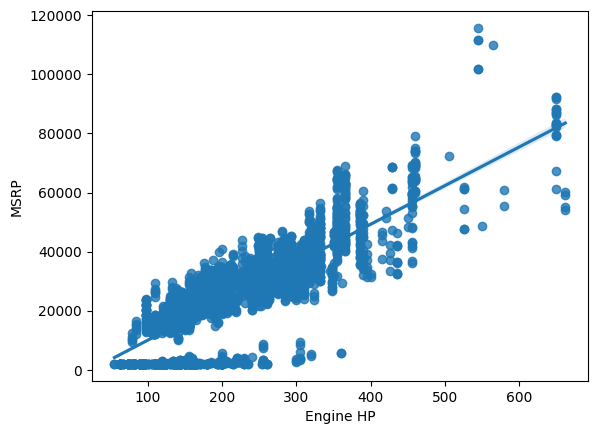

```python
#Pour comparaison, on trace le nuage de points initial
sns.regplot(x='Engine HP', y='MSRP',data=data)
```

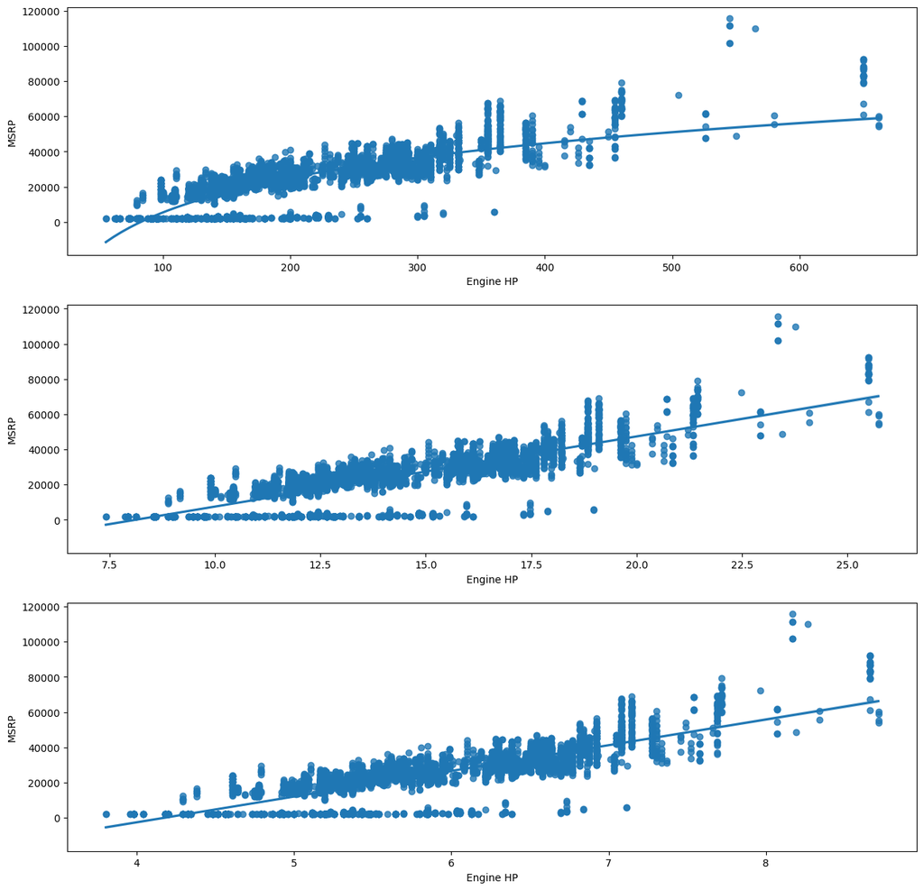

```python
fig, (ax1, ax2,ax3) = plt.subplots(nrows=3, sharey=True,figsize=(15,15))
sns.regplot(x='Engine HP', y='MSRP',data=data,logx=True,ax=ax1)
sns.regplot(x=(data['Engine HP'])**0.5, y=data['MSRP'],ax=ax2)
sns.regplot( x=np.power(data['Engine HP'],1/3), y=data['MSRP'],ax=ax3)
```

```python
print(data['Engine HP'].corr(data['MSRP']))
print(np.log(data['Engine HP']).corr(data['MSRP']))
print(((data['Engine HP'])**0.5).corr(data['MSRP']))
print(np.power(data['Engine HP'],1/3).corr(data['MSRP']))
```

```
0.8012811278371574
0.7709989769617988
0.7926713539241399
0.7868051965469633
```

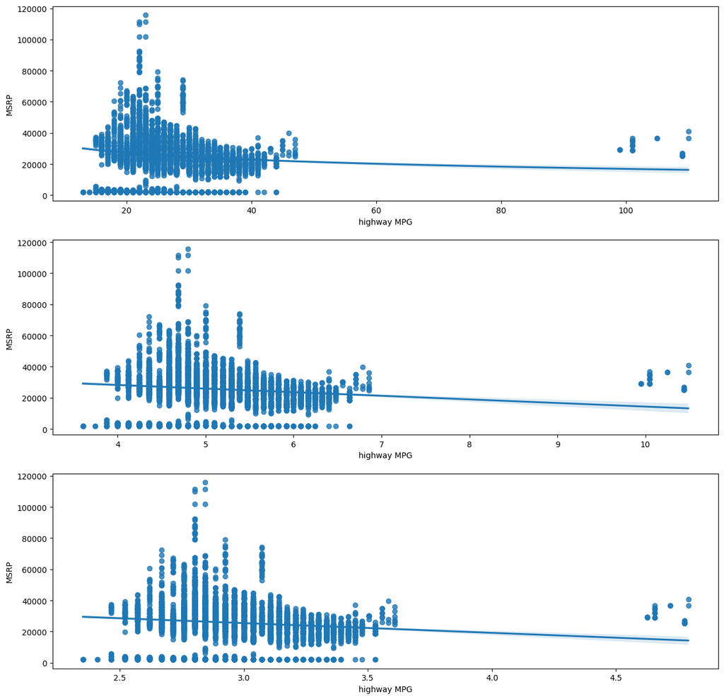

```python
fig, (ax1, ax2,ax3) = plt.subplots(nrows=3, sharey=True,figsize=(15,15))
sns.regplot(x='highway MPG', y='MSRP',data=data,logx=True,ax=ax1)
sns.regplot( x=(data['highway MPG'])**0.5, y=data['MSRP'],ax=ax2)
sns.regplot( x=np.power(data['highway MPG'],1/3), y=data['MSRP'],ax=ax3)
```

```python
print(data['highway MPG'].corr(data['MSRP']))
print(np.log(data['highway MPG']).corr(data['MSRP']))
print(np.power(data['highway MPG'],1/2).corr(data['MSRP']))
print(np.power(data['highway MPG'],1/3).corr(data['MSRP']))
```

```
-0.10434422120544612
-0.11723657488479156
-0.11597216424704117
-0.11743406017035975
```

```python
data['Engine HP r2']=np.power(data['Engine HP'],1/2)
data['highway MPG r3']=np.power(data['highway MPG'],1/3)
```

```python
#On crée l'objet 'scale'
list_std=['Age','Engine HP','highway Lkm','highway MPG r3','Engine HP r2','Age_MPG']
scale = StandardScaler()
#On ajuste nos données à l'objet 'scale'
fit_scale_OH=scale.fit_transform(data[list_std])
#On met sous forme de Dataframe
cols_scaled = pd.DataFrame(fit_scale_OH,columns=list_std)
cols_scaled.reset_index(drop=True, inplace=True)
```

```python
X_trans_OH = pd.concat([cols_scaled, cols_OH], axis=1)
```

```python
X_train=X_trans_OH.iloc[idx]
y_train=data['MSRP'].iloc[idx]
X_test=X_trans_OH.iloc[idxT]
y_test=data['MSRP'].iloc[idxT]
score_model_1(X_train,y_train,X_test,y_test)
print('\n')
score_model_2(X_train,y_train,X_test,y_test)
```

```
Temps d execution du modèle 1 : 1.939130e-02
Score MSE sur le modele 1 :
2.768938e+07
Score R2 sur le modele 1 :
0.8513783449914263


Temps d execution du modèle 2 : 2.164013e-01
Score MSE sur le modele 2 :
2.775670e+07
Score R2 sur le modele 2 :
0.8510170381366851
```

Retour à la table des matières

## 4 Et les variables catégorielles ?

### 4-1 Sont-elles toutes déterminantes ?

> Tâche 25. Si certaines features sont très corrélées avec d'autres, ou bien si elles sont complètement sans effet sur le prédicteur, cela peut diminuer les résultats d'un modèle. Les résultats sont-ils meilleurs avec ou sans les variables 'Vehicle size' et 'Number of Doors' ? Pouvait-on le prévoir ?

```python
list(X_trans_OH.columns)
```

```
['Age',
 'Engine HP',
 'highway Lkm',
 'highway MPG r3',
 'Engine HP r2',
 'Age_MPG',
 'Make_Chevrolet',
 'Make_Chrysler',
 'Make_Ford',
 'Make_Honda',
 'Make_Hyundai',
 'Make_Mazda',
 'Make_Nissan',
 'Make_Pontiac',
 'Make_Subaru',
 'Make_Suzuki',
 'Transmission Type_AUTOMATED_MANUAL',
 'Transmission Type_AUTOMATIC',
 'Transmission Type_DIRECT_DRIVE',
 'Transmission Type_MANUAL',
 'Transmission Type_UNKNOWN',
 'Driven_Wheels_all wheel drive',
 'Driven_Wheels_four wheel drive',
 'Driven_Wheels_front wheel drive',
 'Driven_Wheels_rear wheel drive',
 'Vehicle Style_2dr Hatchback',
 'Vehicle Style_2dr SUV',
 'Vehicle Style_4dr Hatchback',
 'Vehicle Style_4dr SUV',
 'Vehicle Style_Cargo Minivan',
 'Vehicle Style_Cargo Van',
 'Vehicle Style_Convertible',
 'Vehicle Style_Convertible SUV',
 'Vehicle Style_Coupe',
 'Vehicle Style_Crew Cab Pickup',
 'Vehicle Style_Extended Cab Pickup',
 'Vehicle Style_Passenger Minivan',
 'Vehicle Style_Passenger Van',
 'Vehicle Style_Regular Cab Pickup',
 'Vehicle Style_Sedan',
 'Vehicle Style_Wagon',
 'Engine Fuel Type_diesel',
 'Engine Fuel Type_electric',
 'Engine Fuel Type_flex-fuel',
 'Engine Fuel Type_natural gas',
 'Engine Fuel Type_unleaded',
 'Vehicle Size_0',
 'Vehicle Size_1',
 'Vehicle Size_2',
 'Number of Doors_2.0',
 'Number of Doors_3.0',
 'Number of Doors_4.0',
 'Engine Cylinders_0.0',
 'Engine Cylinders_2.0',
 'Engine Cylinders_3.0',
 'Engine Cylinders_4.0',
 'Engine Cylinders_5.0',
 'Engine Cylinders_6.0',
 'Engine Cylinders_8.0']
```

```python
X_train=X_trans_OH.iloc[idx].drop([ 'Vehicle Size_0',
 'Vehicle Size_1',
 'Vehicle Size_2',],axis=1)
y_train=data['MSRP'].iloc[idx]
X_test=X_trans_OH.iloc[idxT].drop([ 'Vehicle Size_0',
 'Vehicle Size_1',
 'Vehicle Size_2',],axis=1)
y_test=data['MSRP'].iloc[idxT]
score_model_1(X_train,y_train,X_test,y_test)
print('\n')
score_model_2(X_train,y_train,X_test,y_test)
```

```
Temps d execution du modèle 1 : 3.160167e-02
Score MSE sur le modele 1 :
2.769738e+07
Score R2 sur le modele 1 :
0.8513354350158457


Temps d execution du modèle 2 : 2.271094e-01
Score MSE sur le modele 2 :
2.772316e+07
Score R2 sur le modele 2 :
0.8511970278639178
```

> Il existe des méthodes rigoureuses pour choisir les variables les plus pertinentes. Cela s'appelle la *sélection de features* et fait l'objet d'un cours en particulier pour ceux d'entre vous qui continueront un cursus data science.

> Tâche 26 Traçons le nuage de points de la feature 'MSPR' en fonction de 'highway MPG' avec les labels des classes de 'Transmission Type'. Commentez.

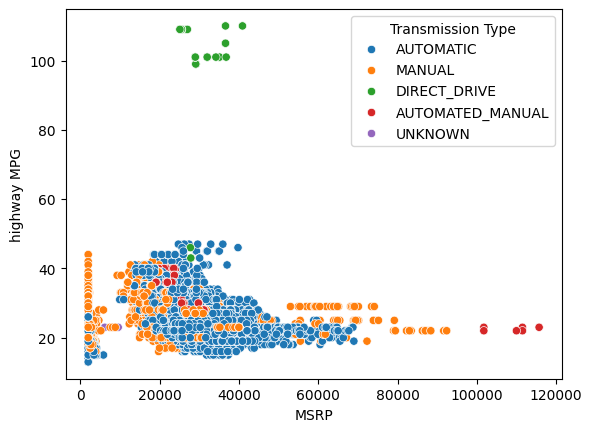

```python
sns.scatterplot(x="MSRP", y="highway MPG", hue="Transmission Type",data=data)
```

> Commentaire. On voit que la catégorie 'DIRECT_DRIVE' de la variable 'Transmission Type' contribue à expliquer la relation entre 'highway MPG' et le prix : elle explique bien le groupe de points avec un 'highway HP' très élevé par rapport au reste du nuage de points. Ainsi, même si à partir du boxplot 'Transmission Type' par 'MSRP', on serait tenté d'enlever la variable 'Transmission Type', on voit qu'elle fait partie d'une relation 'highway MPG'/'MSPR'/'Transmission Type' : on perdrait de l'information en l'enlevant et on dégraderait potentiellement nos scores.

Retour à la table des matières

Retour à la table des matières